# Age-structure

11/20/2022

## Aim of these experiments

- Recover a time-varying infectivity parameter in an age-structured SIR with a simple SIR.
- Develop an expert system that detects structural changes.

| **Algorithm**: Moving windows. |
| --- |

1. Set up initial values for the parameter.
2. For a given window length, estimate the parameters of the model.
3. Set up the parameters as the new initial values.
4. Move the window a given step length.
5. Repeat 2-4 until a desired condition.

## Let’s have a look at the data

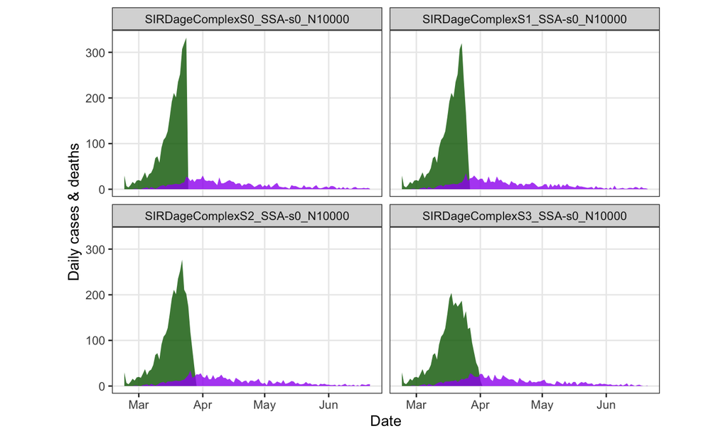

S{0, 1, 2, 3} differ on the length of the reduction in infectivity.

## First try – S0_SSA-s0_N10000

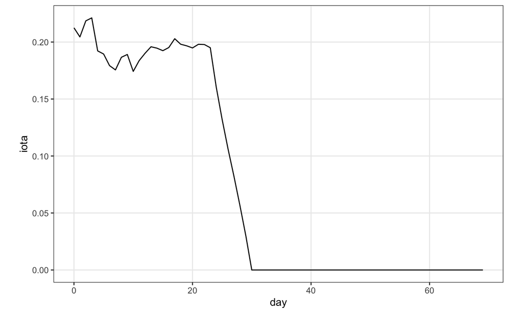

Daily re-parametrization. Window length = 7d.

## Four scenarios - seed 0

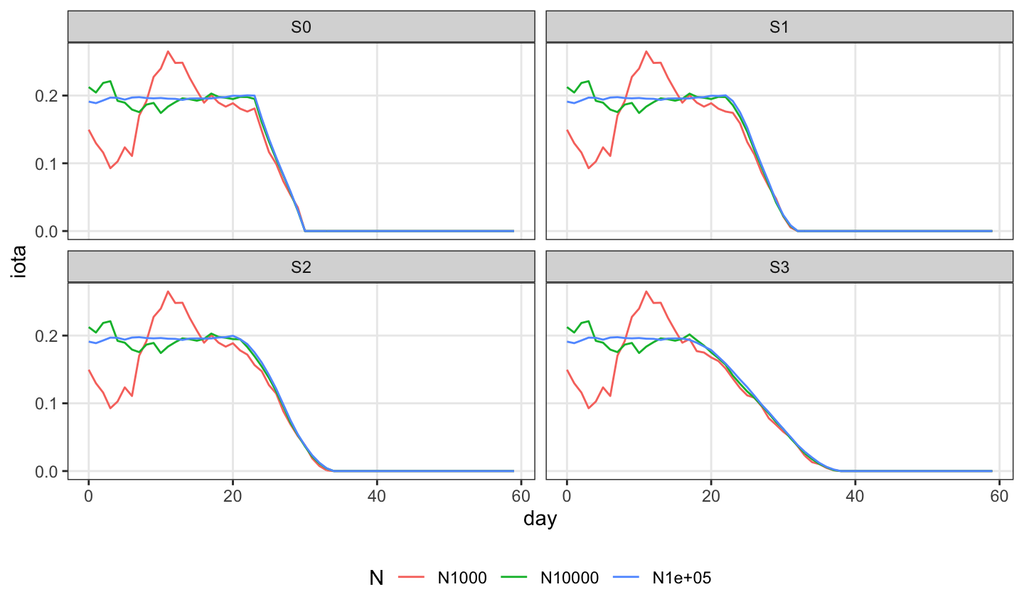

Variability decreases with N. Remember \(\iota = .2\)

## Structural breaks in infectivity.

*Chow test*.

We split the data in two groups:

\[ y_t=a_1+b_1x_{1t} + c_1x_{2t} + \varepsilon \, \]

\[ y_t=a_2+b_2x_{1t} + c_2x_{2t} + \varepsilon \]

So, our null hypothesis is \(a_1=a_2\), \(b_1=b_2\), and \(c_1=c_2\).

The test statistic follows an F-distribution with \(N - 2k\) d.o.f.

## Example – S0_SSA-s0_N10000

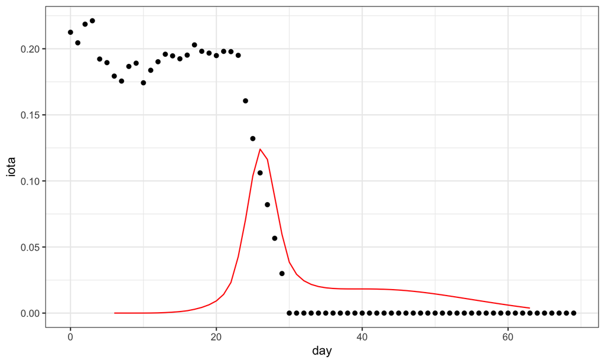

Red line – statistic.

## Parametrizing the break

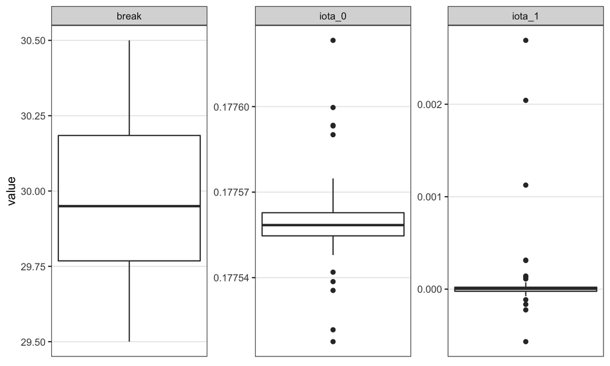

The break is recovered nicely.

## Effect of window length

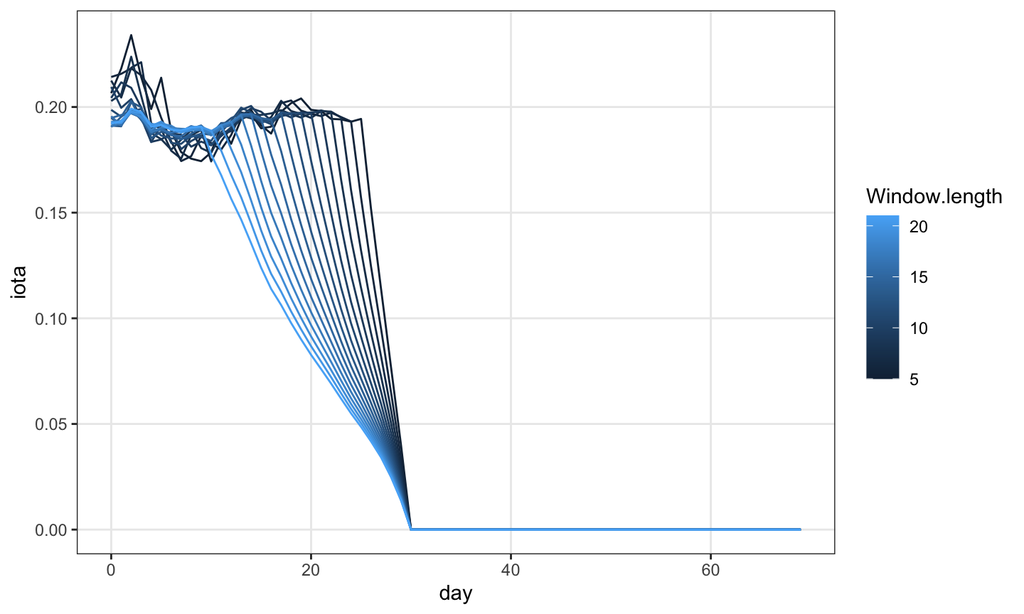

## Chow-test

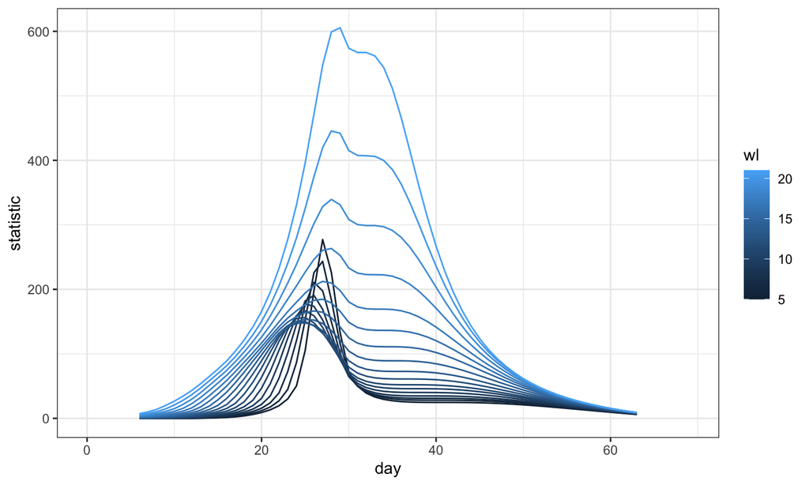

On the infectivities.

## Findings so far

- For this simple setting, the moving window suffices to find the structural change.
- Incorporating the breakpoint in parameter estimation also helps us find the structural change.
- Chow tests in the infectivity series do not give exact information on when the change happened.

## What about smaller drops?

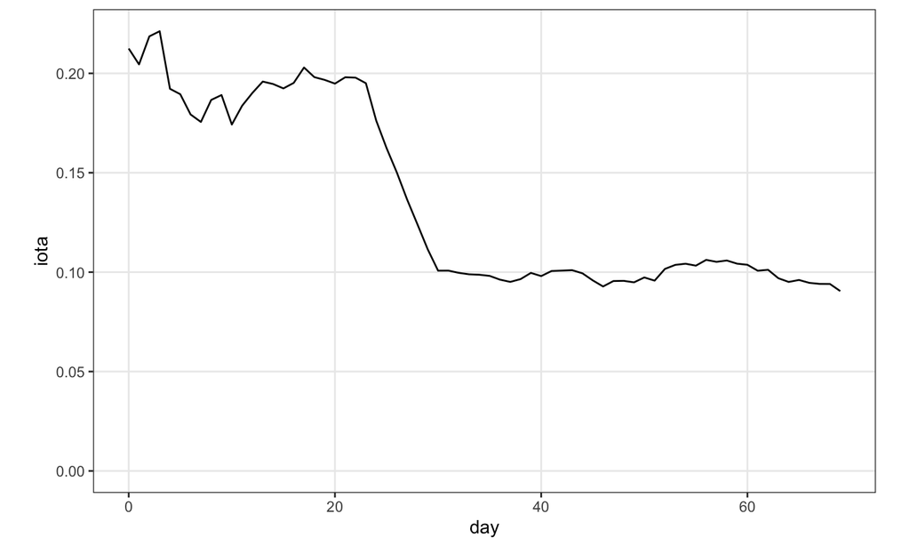

Let’s try with a iota reduction of .5, 7d window.

## Window length reveals lockdown

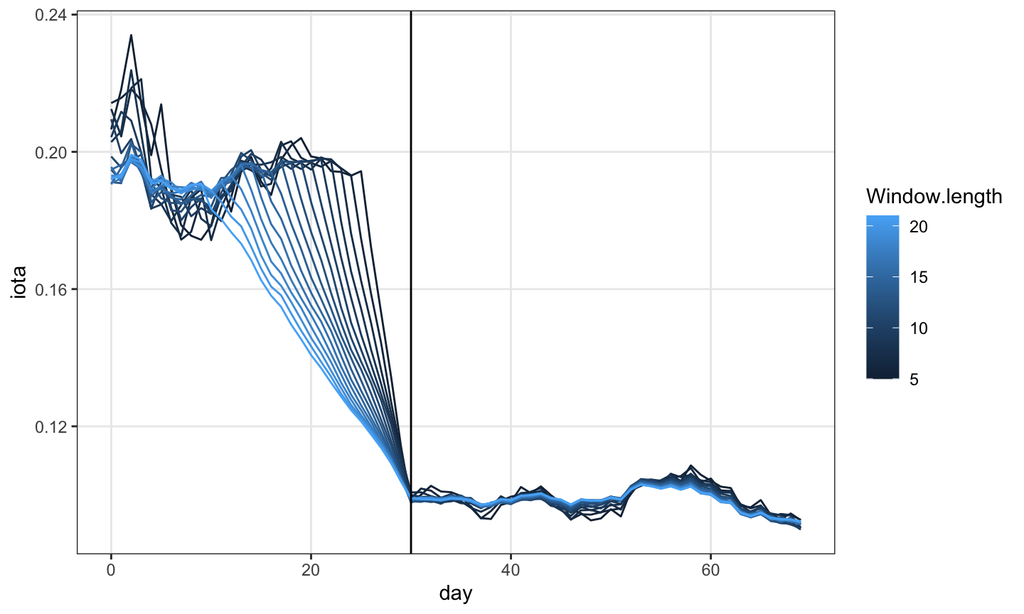

The lockdown started on day 30. Iota factor .5

## Let’s see with lesser drops (I)

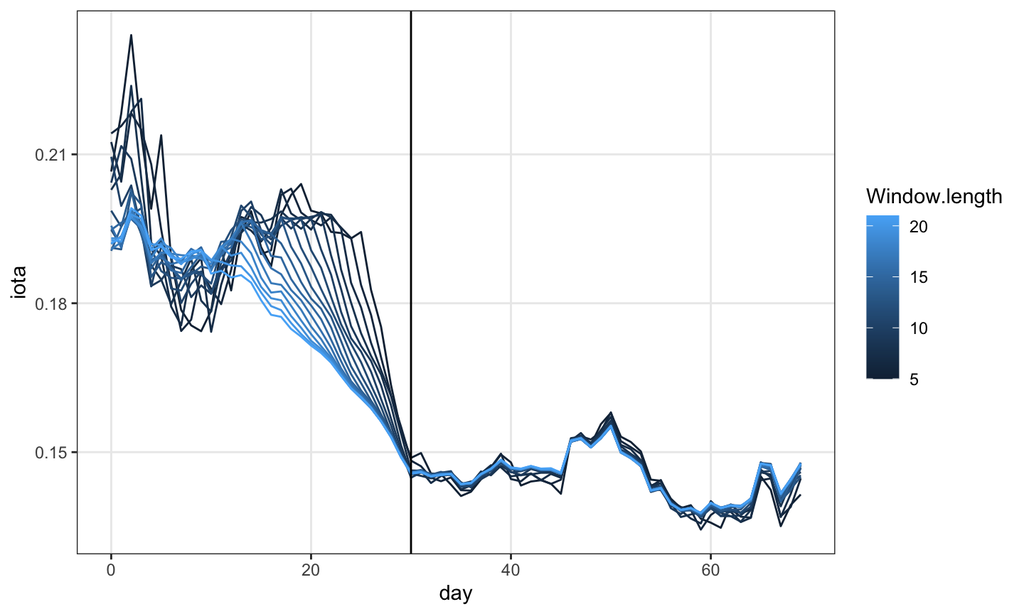

There’s a bit more variance now. Factor .75

## Let’s see with lesser drops (II)

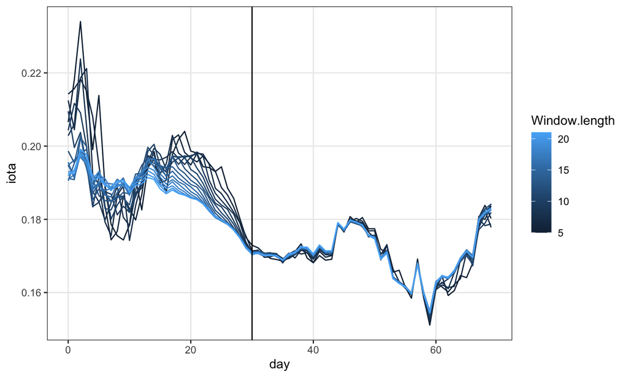

It’s more difficult to see the exact day of the lockdown. Factor .875

## More open questions

- What about goodness of fit/prediction?
- More unknown parameters?

## Next step

- Evaluate goodness of fit/prediction.
- Now, parameters are equal for all ages. What if we have parameters that are not equal and changing?